# Multiple Linear Regression MLR

MLR is an *extension* of **SLR**, mathematically it can be expressed as:

$$y = b_0 + b_1x_1 + b_2x_2 +..b_kx_k$$
In this model, we have more than one *independent* variable affecting one single *dependent* variable.

### Dummy Variables

These type of variables are used when some of the independent variables in a dataset are **categorigal** (nominal or ordinal). It is important to identify how many different categories the variable holds, once that is done a column (new variable) has to be generated for each category.

The following image clarifies this concept using an image from a business analytics excercise:

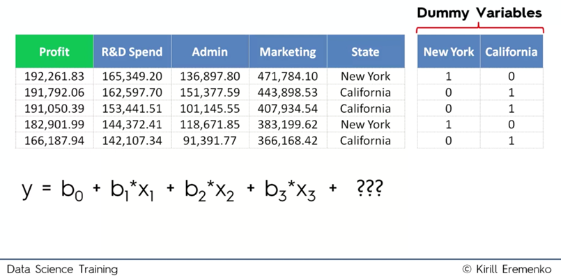

These variables are of a **binary** nature.

#### The Dummy Variable Trap

- The phenomenon in which one or more independent variables in a linear regression model predict another one ($D_2 = 1-D_1 \therefore{} D_1 = 1-D_2$) is called [**multicollinearity**](http://blog.minitab.com/blog/adventures-in-statistics-2/what-are-the-effects-of-multicollinearity-and-when-can-i-ignore-them).
- Therefore one should always leave one dummy variable out of the equation, indistinctly of the ammount of dummy variables generated.
- **Important Tip**:The process of using all but one dummy variable has to be applyed to each set of these variables generated.

### Constructing a Model

There are 5 methods for constructing a model:

1. All-in
2. Backward Elimination
3. Forward Selection
4. Bidirectional Elimination
5. Score Comparison

#### All-in

It referes to the variables, where **all** of them are considered in making the model. This is usually done when:

- There is prior domain knowledge.
- It has to be done this way.
- In preparation for *Backward Elimination*.

#### Backwaerd Elimination

Steps to follow:

1. Select a significance level to stay in the model (e.g.SL = 0.05)
2. Fit the full model with all possible predictors
3. Consider the predictor with the **highest** P-value. If P > SL, then move on to step 4, otherwise your model is ready.
4. Remiove the predictor.
5. Fit model without this variable and go back to step 3.

#### Forward Selection

Steps to follow:

1. Select a significance level to enter the model (SL = 0.05)
2. Fit all simple regression models $y \text{~} x_n$. Select the one with the lowest P-value.
3. Keep this variable and fit all possible models with one extra predictor added to the one(s) you already have.
4. Consider the predictor with the **lowest** P-value out of step 3. If P < SL, go to Step 3, otherwise your model is finished.

#### Bidirectional Elimination

Steps to follow:

1. Select a significance level to enter and to stay in the model (e.g SLENTER = 0.05, SLSTAY = 0.05)
2. Perform the next step of **Forward Selection** (new variables must have: P < SLENTER to enter)
3. Perform **ALL** steps of *Backward Elimination* (old variables must have P < SLSTAY to stay). Go back to Step 2.
4. No new variables can enter and no old variables can exit. Model is ready.

#### Score Comparison or *All Posible Models*

Steps to Follow:

1. Select a criterion of goodness of fit (e.g. Akaike criterion, $r^2$, etc)
2. Construct all possible regression models: $2^N-1$ total combinatios.
3. Select the one with the best criterion.
4. Model is ready.